# Kpop Report

Jason Liu, Dillon Tsien, Simon Wu, Ken Huang

11/21/2021

# Introduction

We found K-Pop to be a good topic because it’s a media data landscape that is rife with layers of racialization and gender. We thought it would be particularly interesting to compare the global data trends of K-Pop, especially being situated in a very Western data context at UW. Finally, we all found a racial connection to the topic; living in the diaspora of Asian-America, understanding the reach of a very much Asian (without American)-based phenomenon in the US produces layers of personal significance and self-reflexivity in understanding and re-articulating the “Asian-ness” that we’ve been dispossessed of.

We will be using the “K-Pop Hits Through The Years” dataset which contains hit/top songs in K-Pop from the 90s to the latest year using Apple Music and Spotify. Each song contains information such as its danceability, energy, loudness, and more. The dataset was obtained from [here](https://www.kaggle.com/sberj127/kpop-hits-through-the-years?select=KPopHits2000.csv).

# Summary

# Table

The table displays the overall means of the five variables, grouped by year. We chose these specific values because they all have intuitive positive correlations with popularity, and seem more fundamental components to the songs over things like key (which is hard to correlate numerically), duration, time signature, etc.)

| Year | Danceability | Energy | Loudness | Speechiness | Acousticness |
| --- | --- | --- | --- | --- | --- |
| 1990 | 0.629 | 0.655 | -8.789 | 0.046 | 0.250 |
| 2000 | 0.606 | 0.676 | -6.618 | 0.059 | 0.240 |
| 2001 | 0.606 | 0.616 | -7.617 | 0.049 | 0.277 |
| 2002 | 0.607 | 0.590 | -6.626 | 0.063 | 0.361 |
| 2003 | 0.625 | 0.623 | -6.061 | 0.050 | 0.293 |
| 2004 | 0.614 | 0.652 | -6.538 | 0.054 | 0.330 |
| 2005 | 0.576 | 0.617 | -5.483 | 0.048 | 0.378 |
| 2006 | 0.591 | 0.612 | -6.165 | 0.045 | 0.319 |
| 2007 | 0.604 | 0.674 | -6.003 | 0.049 | 0.271 |
| 2008 | 0.652 | 0.707 | -5.749 | 0.068 | 0.286 |
| 2009 | 0.665 | 0.699 | -5.539 | 0.086 | 0.277 |
| 2010 | 0.676 | 0.768 | -4.797 | 0.065 | 0.197 |
| 2011 | 0.635 | 0.709 | -5.605 | 0.073 | 0.284 |
| 2012 | 0.668 | 0.762 | -4.416 | 0.082 | 0.190 |
| 2013 | 0.668 | 0.753 | -4.423 | 0.091 | 0.272 |
| 2014 | 0.603 | 0.653 | -5.464 | 0.083 | 0.359 |
| 2015 | 0.654 | 0.785 | -3.834 | 0.100 | 0.196 |
| 2016 | 0.622 | 0.656 | -4.695 | 0.071 | 0.357 |
| 2017 | 0.684 | 0.765 | -4.039 | 0.098 | 0.208 |
| 2018 | 0.677 | 0.754 | -4.298 | 0.092 | 0.202 |
| 2019 | 0.694 | 0.772 | -4.091 | 0.096 | 0.142 |
| 2020 | 0.681 | 0.834 | -3.499 | 0.086 | 0.091 |

# Chart 1

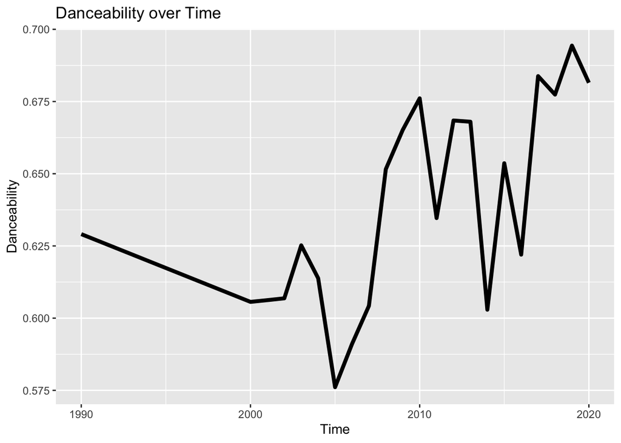

This is a line chart for the danceability of the top hits from 1990 to 2020. The data is aggregated to the year level and shows an overall increase to the danceability of top Kpop hits as well as a few dips between 2010 and 2020. The purpose of the graph is to demonstrate a correlation between danceability and time, which is a good indicator of Kpop songs and their relative popularity and its change over time. Although there are many other features in the Kpop data set that can be displayed over time such as energy or loudness, the scale is not the same and the resulting graph may be misleading. In the graph we can also see that the minimum is around 2005 while the maximum is around 2019.

# Chart 2

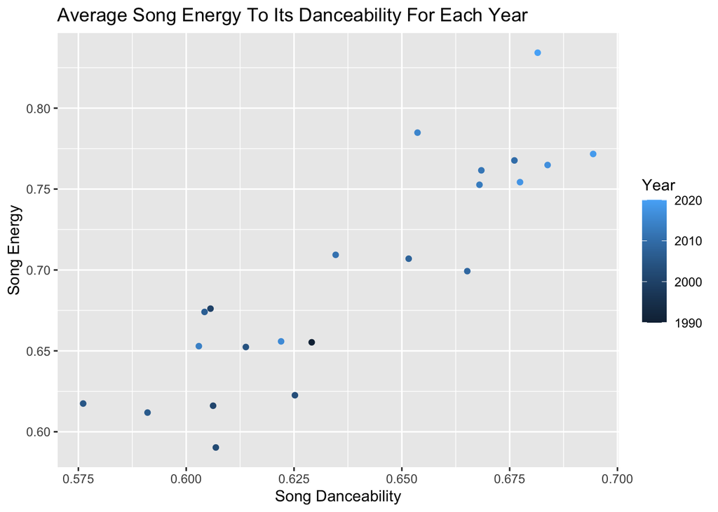

This chart is intended to show the relationship between a songs energy and its danceability (mean value of all the songs for each year). The purpose of this chart is to understand the relationships between two variables of energy and danceability and to notice any dense areas in the scatterplot that would correlate to an optimal level of danceability and energy. Based on the chart, there is a moderate positive correlation between song energy and danceability. Moreover, newer released songs tend to have a higher song energy and danceability value/score than older songs.

# Chart 3

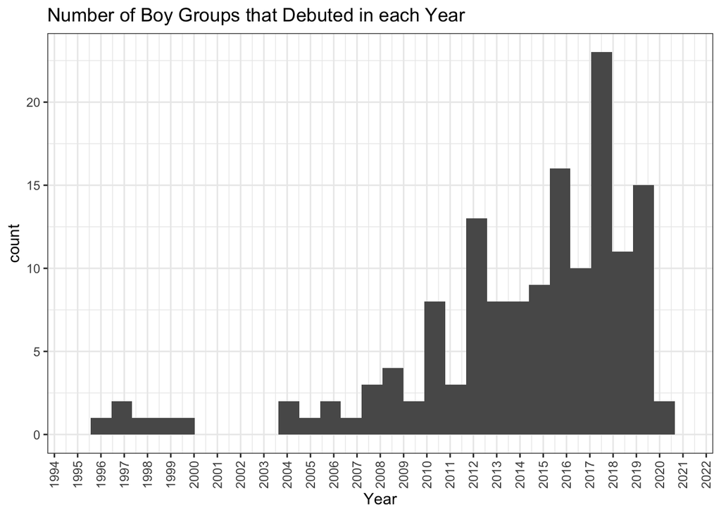

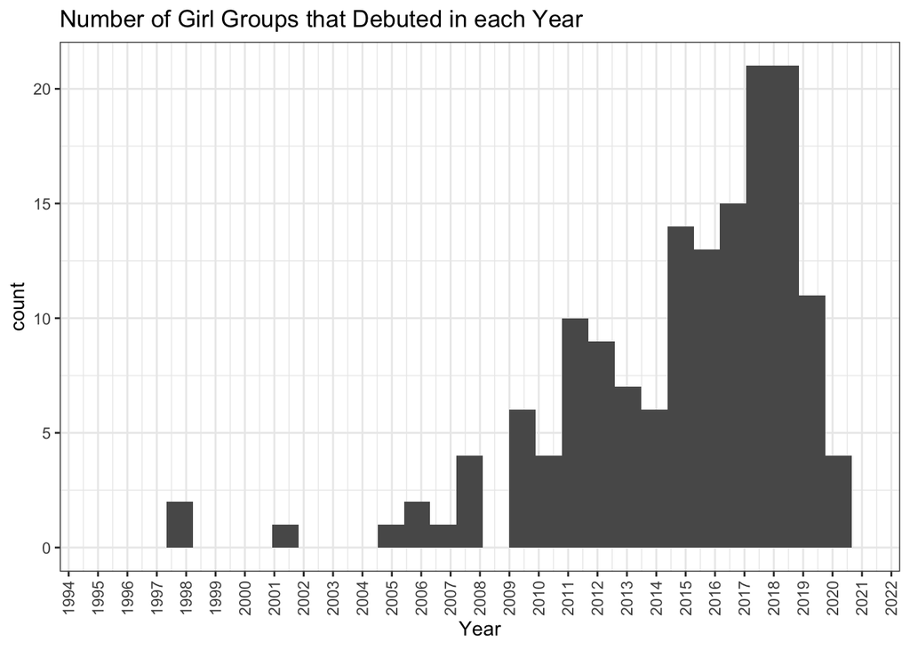